# HW6

## Study Question 2

A DAG encodes conditional independence between variables, and such relatinoship is implied by d-spearation.

$$(Y \perp\!\!\!\perp_d X | S)_\text{G} \implies Y \perp\!\!\!\perp X | S$$

A set of variables $S$ d-separates $X$ and $Y$ in a DAG G when the variables in $S$ block all the paths between $X$ and $Y$. A path is blocked if and only if:

1. A non-collider in the subset of nodes is conditioned on, or
2. A collider in the subset of nodes is not contitioned on and has no descendents which is conditioned on.

The ‘dagitty’ package applies these criteria for d-separation to identify the testable implications of conditional indenpendence between two variables in a DAG.

### Part A

Here we plot the DAG of Peal’s example and print all the testable conditional independence relationships implied by this DAG.

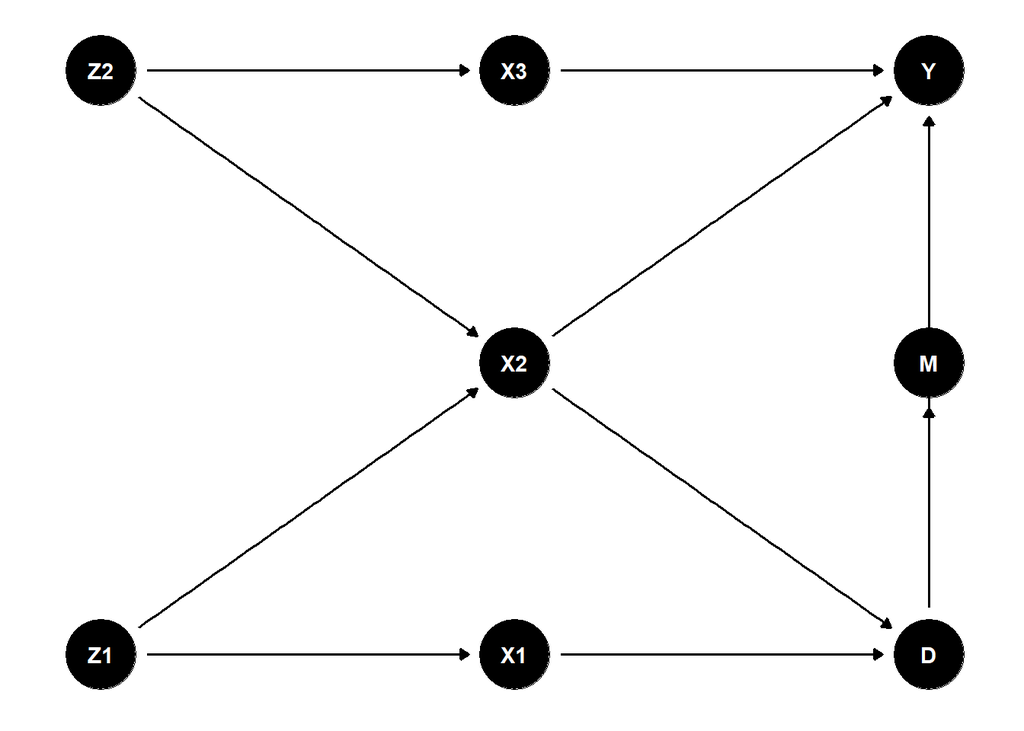

```r
library(dagitty)
library(ggdag)
G1 = dagitty(
  'dag{
    Z1 [pos = "-1, -1"]
    X1 [pos = "0, -1"]
    Z2 [pos = "-1, 1"]
    X3 [pos = "0, 1"]
    Y [outcome, pos = "1, 1"]
    D [exposure, pos = "1, -1"]
    M [mediator, pos = "1, 0"]
    X2 [pos = "0, 0"]
    Z1 -> X1
    X1 -> D
    Z1 -> X2
    Z2 -> X3
    X3 -> Y
    Z2 -> X2
    D -> Y
    X2 -> Y
    X2 -> D
    M -> Y
    D -> M
  }'
)
ggdag(G1) + theme_dag()
```

```r
print(impliedConditionalIndependencies(G1))
```

```
## D _||_ X3 | Z2
## D _||_ X3 | X2, Z1
## D _||_ X3 | X1, X2
## D _||_ Z1 | X1, X2
## D _||_ Z2 | X2, Z1
## D _||_ Z2 | X1, X2
## M _||_ X1 | D
## M _||_ X2 | D
## M _||_ X3 | Z2
## M _||_ X3 | X2, Z1
## M _||_ X3 | X1, X2
## M _||_ X3 | D
## M _||_ Z1 | X1, X2
## M _||_ Z1 | D
## M _||_ Z2 | X2, Z1
## M _||_ Z2 | X1, X2
## M _||_ Z2 | D
## X1 _||_ X2 | Z1
## X1 _||_ X3
## X1 _||_ Y | D, X2, X3
## X1 _||_ Y | D, X2, Z2
## X1 _||_ Y | D, X2, Z1
## X1 _||_ Z2
## X2 _||_ X3 | Z2
## X3 _||_ Z1
## Y _||_ Z1 | X1, X2, Z2
## Y _||_ Z1 | D, X2, Z2
## Y _||_ Z1 | X1, X2, X3
## Y _||_ Z1 | D, X2, X3
## Y _||_ Z2 | X2, X3, Z1
## Y _||_ Z2 | X1, X2, X3
## Y _||_ Z2 | D, X2, X3
## Z1 _||_ Z2
```

### Part B

Please see below the DAG with variables $D$, $Y$, $X_2$ and $X_3$ as well as testable restrictions implied by this DAG.

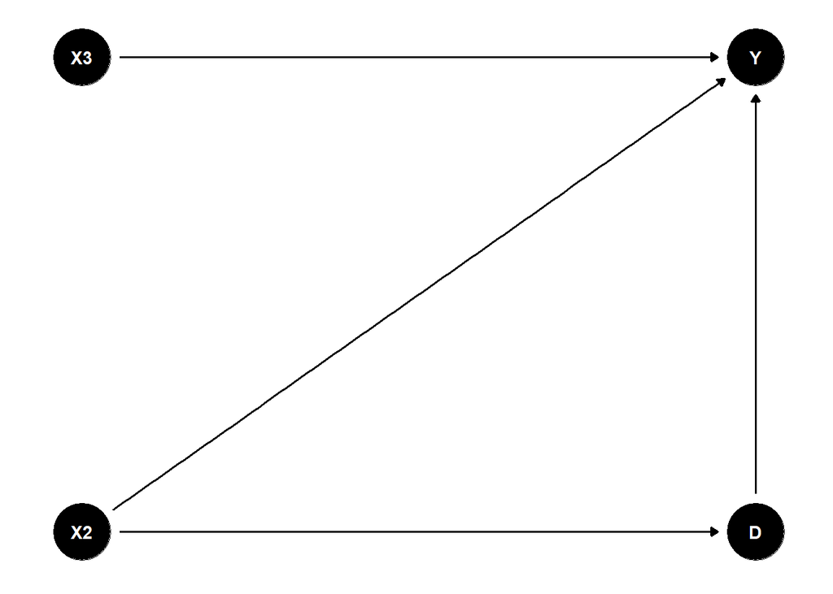

```r
G2 = dagitty(
  'dag{
    X3 [pos = "0, 1"]
    Y [outcome, pos = "1, 1"]
    D [exposure, pos = "1, 0"]
    X2 [pos = "0, 0"]
    X3 -> Y
    D -> Y
    X2 -> Y
    X2 -> D
  }'
)
ggdag(G2) + theme_dag()
```

```r
print(impliedConditionalIndependencies(G2))
```

```
## D _||_ X3
## X2 _||_ X3
```

### Part C

Please see below the DAG with variables $D$, $Y$ and $X_2$. There is no testable restriction implied by this DAG.

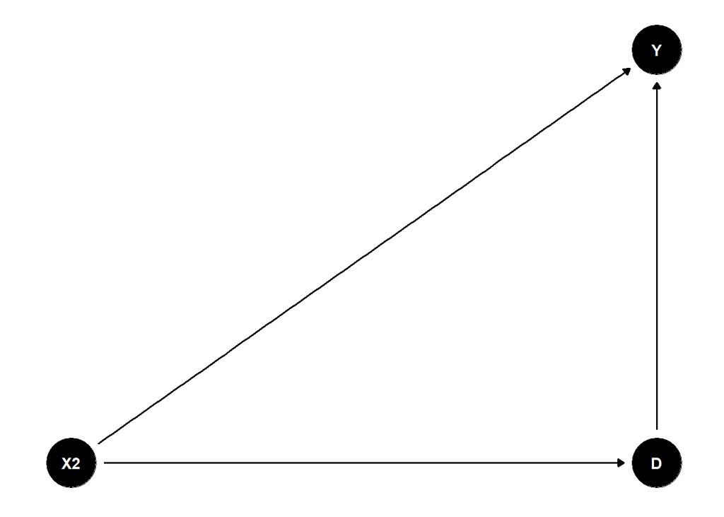

```r
G3 = dagitty(
  'dag{
    Y [outcome, pos = "1, 1"]
    D [exposure, pos = "1, 0"]
    X2 [pos = "0, 0"]
    D -> Y
    X2 -> Y
    X2 -> D
  }'
)
ggdag(G3) + theme_dag()
```

```r
print(impliedConditionalIndependencies(G3))
```

### Part D

Please see below the DAG with all the variables in Pearl’s example except for $X_3$ as well as testable restrictions implied by this DAG.

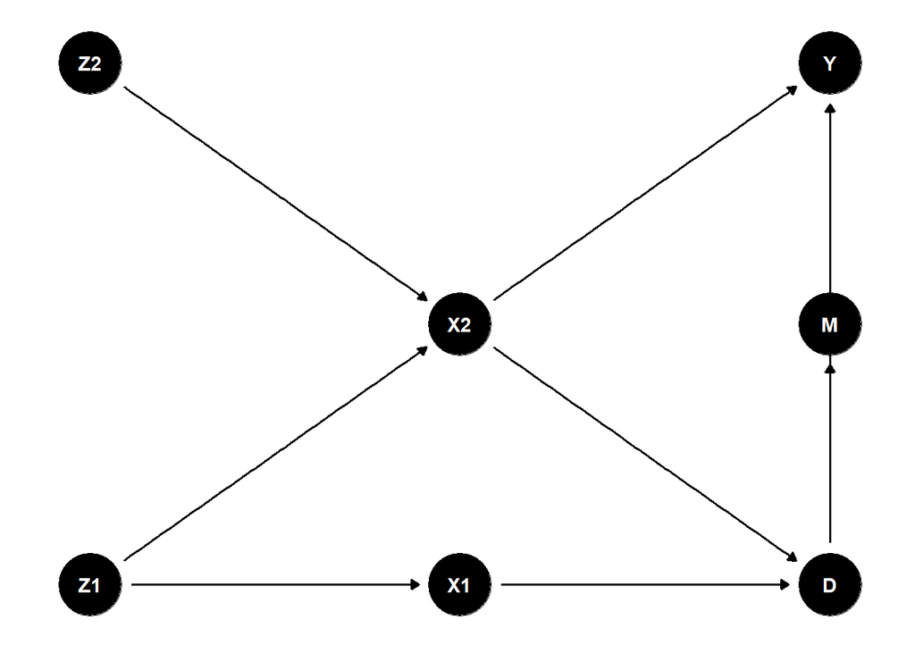

```r
G4 = dagitty(
  'dag{
    Z1 [pos = "-1, -1"]
    X1 [pos = "0, -1"]
    Z2 [pos = "-1, 1"]
    Y [outcome, pos = "1, 1"]
    D [exposure, pos = "1, -1"]
    M [mediator, pos = "1, 0"]
    X2 [pos = "0, 0"]
    Z1 -> X1
    X1 -> D
    Z1 -> X2
    Z2 -> X2
    D -> Y
    X2 -> Y
    X2 -> D
    M -> Y
    D -> M
  }'
)
ggdag(G4) + theme_dag()
```

```r
print(impliedConditionalIndependencies(G4))
```

```
## D _||_ Z1 | X1, X2
## D _||_ Z2 | X2, Z1
## D _||_ Z2 | X1, X2
## M _||_ X1 | D
## M _||_ X2 | D
## M _||_ Z1 | X1, X2
## M _||_ Z1 | D
## M _||_ Z2 | X2, Z1
## M _||_ Z2 | X1, X2
## M _||_ Z2 | D
## X1 _||_ X2 | Z1
## X1 _||_ Y | D, X2
## X1 _||_ Z2
## Y _||_ Z1 | X1, X2
## Y _||_ Z1 | D, X2
## Y _||_ Z2 | X2, Z1
## Y _||_ Z2 | X1, X2
## Y _||_ Z2 | D, X2
## Z1 _||_ Z2
```

### Part E

Please see below the DAG with the arrow between $D$ and $X_2$ reversed as well as testable restrictions implied by this DAG.

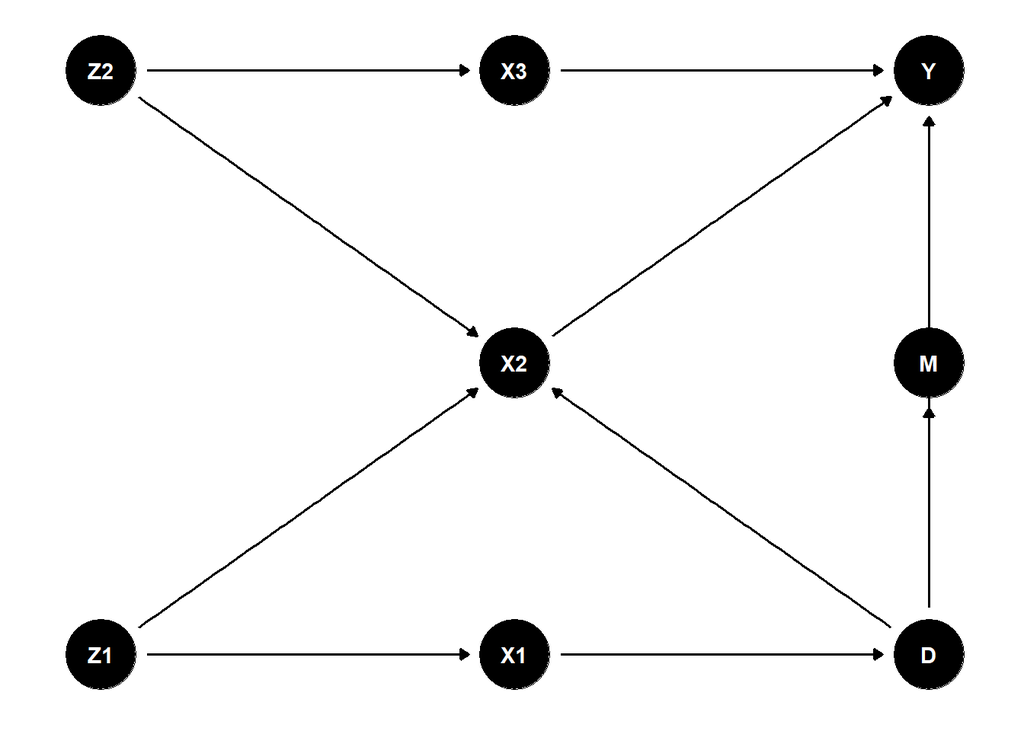

```r
G5 = dagitty(
  'dag{
    Z1 [pos = "-1, -1"]
    X1 [pos = "0, -1"]
    Z2 [pos = "-1, 1"]
    X3 [pos = "0, 1"]
    Y [outcome, pos = "1, 1"]
    D [exposure, pos = "1, -1"]
    M [mediator, pos = "1, 0"]
    X2 [pos = "0, 0"]
    Z1 -> X1
    X1 -> D
    Z1 -> X2
    Z2 -> X3
    X3 -> Y
    Z2 -> X2
    D -> Y
    X2 -> Y
    D -> X2
    M -> Y
    D -> M
  }'
)
ggdag(G5) + theme_dag()
```

```r
print(impliedConditionalIndependencies(G5))
```

```
## D _||_ X3
## D _||_ Z1 | X1
## D _||_ Z2
## M _||_ X1 | D
## M _||_ X2 | D
## M _||_ X3
## M _||_ Z1 | X1
## M _||_ Z1 | D
## M _||_ Z2
## X1 _||_ X2 | D, Z1
## X1 _||_ X3
## X1 _||_ Y | D, X2, X3
## X1 _||_ Y | D, X2, Z2
## X1 _||_ Y | D, Z1
## X1 _||_ Z2
## X2 _||_ X3 | Z2
## X3 _||_ Z1
## Y _||_ Z1 | D, X2, Z2
## Y _||_ Z1 | D, X2, X3
## Y _||_ Z2 | D, X2, X3
## Z1 _||_ Z2
```